# Mixed Model Workshop part 3

# 5 Post-hocs

Here I will use the glht function from multcomp package to perform post-hoc analyses.

## 5.1 Tukey comparison

Usually you see that on internet

```r
summary(glht(lme.conv, linfct = mcp(group = "Tukey")),test=adjusted("none"))
```

```
##
##   Simultaneous Tests for General Linear Hypotheses
##
## Multiple Comparisons of Means: Tukey Contrasts
##
##
## Fit: lmer(formula = rt ~ group * session + (1 + session | participant) +
##     (1 | item), data = data)
##
## Linear Hypotheses:
##                     Estimate Std. Error z value Pr(>|z|)
## test - control == 0    5.373     13.390   0.401    0.688
## (Adjusted p values reported -- none method)
```

Warning, Tukey means that you compare all levels against each other. You test for all possible comparisons. But it is not a Tukey correction. Here there is no correction for multiple comparison `test=adjusted("none")`.

> Note that again, the results gives you the comparison at T0

## 5.2 How to define a contrast ? OR Why I’ve been annoying you with math

Another way to do post-hocs is to define the contrast you want to test.

```r
# contrast
KgroupT0 = rbind(c(0,1,0,0))
# testing for the contrast, with no correction for multiple comparison :
# we have only one comparison
summary(glht(lme.conv, linfct = KgroupT0),test=adjusted("none"))
```

```
##
##   Simultaneous Tests for General Linear Hypotheses
##
## Fit: lmer(formula = rt ~ group * session + (1 + session | participant) +
##     (1 | item), data = data)
##
## Linear Hypotheses:
##        Estimate Std. Error z value Pr(>|z|)
## 1 == 0    5.373     13.390   0.401    0.688
## (Adjusted p values reported -- none method)
```

Same result.

You see what does not appear in usual outputs : the hypothesis tested is whether the contrast is different from 0. In R the equality test is written `==`.

### 5.2.1 Write down the math of fixed effects for your model

Remember :

rt.mean.bPbS = Intercept + grouptest*group + sessionT1*session + grouptest:sessionT1*group*session

Where

- session = 0 if T0, session = 1 if T1
- group = 0 if control, group = 1 if test
- Intercept is the mean in ref level (session = 0, group = 0)

WARNING : in the same order as in the model, you start building a table :

| rt = | Intercept | + (grouptest) x group | + (sessionT1) x session | + (grouptest:sessionT1) x group x session |
| --- | --- | --- | --- | --- |
| contrast |  |  |  |  |

```r
summary(glht(lme.conv))
```

```
##
##   Simultaneous Tests for General Linear Hypotheses
##
## Fit: lmer(formula = rt ~ group * session + (1 + session | participant) +
##     (1 | item), data = data)
##
## Linear Hypotheses:
##                          Estimate Std. Error z value Pr(>|z|)
## (Intercept) == 0          986.272     12.343  79.904   <1e-05 ***
## grouptest == 0              5.373     13.390   0.401    0.967
## sessionT1 == 0            -99.746      6.868 -14.523   <1e-05 ***
## grouptest:sessionT1 == 0 -143.428      9.713 -14.766   <1e-05 ***
## ---
## Signif. codes:  0 '***' 0.001 '**' 0.01 '*' 0.05 '.' 0.1 ' ' 1
## (Adjusted p values reported -- single-step method)
```

You always multiply your intercept by one. It is never null, always there in your equation :

| rt = | Intercept | + (grouptest) x group | + (sessionT1) x session | + (grouptest:sessionT1) x group x session |
| --- | --- | --- | --- | --- |
| contrast | 1 |  |  |  |

For test group at T0, group = 1, session = 0 :

| rt = | Intercept | + (grouptest) x group | + (sessionT1) x session | + (grouptest:sessionT1) x group x session |
| --- | --- | --- | --- | --- |
| rt of tests at T0 | 1 | 1 | 0 | 1*0 = 0 |

For test group at T1, group = 1, session = 1 :

| rt = | Intercept | + (grouptest) x group | + (sessionT1) x session | + (grouptest:sessionT1) x group x session |
| --- | --- | --- | --- | --- |
| rt of tests at T0 | 1 | 1 | 0 | 1*0 = 0 |
| rt of tests at T1 | 1 | 1 | 1 | 1*1 = 1 |

> Testing the effect of session in the test group mathematically means testing whether (rt of tests at T1 - rt of tests at T0) is different from 0

| rt = | Intercept | + (grouptest) x group | + (sessionT1) x session | + (grouptest:sessionT1) x group x session |
| --- | --- | --- | --- | --- |
| rt of tests at T0 | 1 | 1 | 0 | 1*0 = 0 |
| rt of tests at T1 | 1 | 1 | 1 | 1*1 = 1 |
| T1 vs T0 for tests | 0 | 0 | 1 | 1 |

The last line is (line 2 - line 1).

Be careful with the direction of your sustraction. It will not change the stats but the sign of the estimate.

Mathematically :

T1 vs T0 for tests = rt of tests at T1 - rt of tests at T0  
rt of tests at T1 - rt of tests at T0 > 0 **means** rt of tests at T1 > rt of tests at T0  
rt of tests at T1 - rt of tests at T0 < 0 **means** rt of tests at T1 < rt of tests at T0

### 5.2.2 Translate into R code

```r
# define the contrast
KsessionTests = rbind(c(0,0,1,1))
# give it a name to keep track (this will appear in the output of the test)
rownames(KsessionTests) = "Session Tests"
# test it (no correction)
summary(glht(lme.conv, linfct = KsessionTests),test=adjusted("none"))
```

```
##
##   Simultaneous Tests for General Linear Hypotheses
##
## Fit: lmer(formula = rt ~ group * session + (1 + session | participant) +
##     (1 | item), data = data)
##
## Linear Hypotheses:
##                    Estimate Std. Error z value Pr(>|z|)
## Session Tests == 0 -243.174      6.868   -35.4   <2e-16 ***
## ---
## Signif. codes:  0 '***' 0.001 '**' 0.01 '*' 0.05 '.' 0.1 ' ' 1
## (Adjusted p values reported -- none method)
```

The effect of session is significant in the test group. Reaction times are shorter at T1 by 243 ms in this group.

We can verify this result by releveling the group factor in the model to define the test group as the reference.

*sessionT1* will be the effect of session in the reference group ie the test group :

```r
lme.group.relevel = lmer(rt ~ relevel(group, ref = "test") * session +
                              (1 + session | participant) + (1 | item),
                         data = data.post)
lme.group.relevel
```

```
## Linear mixed model fit by REML ['lmerMod']
## Formula: rt ~ relevel(group, ref = "test") * session + (1 + session |
##     participant) + (1 | item)
##    Data: data.post
## REML criterion at convergence: 20776.63
## Random effects:
##  Groups      Name        Std.Dev. Corr
##  participant (Intercept) 51.73
##              sessionT1   37.25    0.91
##  item        (Intercept) 15.84
##  Residual                16.56
## Number of obs: 2400, groups:  participant, 60; item, 4
## Fixed Effects:
##                                   (Intercept)
##                                       991.645
##           relevel(group, ref = "test")control
##                                        -5.373
##                                     sessionT1
##                                      -243.174
## relevel(group, ref = "test")control:sessionT1
##                                       143.428
```

### 5.2.3 Correct for multiple comparisons

As we have done for the session effect in the test group, we can define the contrast for the effect of session in the control group :

| rt = | Intercept | + (grouptest) x group | + (sessionT1) x session | + (grouptest:sessionT1) x group x session |
| --- | --- | --- | --- | --- |
| rt of controls at T1 | 1 | 0 | 1 | 0*1 = 0 |
| rt of controls at T0 | 1 | 0 | 0 | 0*0 = 0 |
| T1 vs T0 for controls | 0 | 0 | 1 | 0 |

```r
# define the contrast for the sontrol groups
KsessionControls = rbind(c(0,0,1,0))
# give it a name to keep track
rownames(KsessionControls) = "Session Controls"
# combine the two contrasts
Ksession = rbind(KsessionControls,KsessionTests)
# test it and control for multiple comparison with bonferroni correction
summary(glht(lme.conv, linfct = Ksession),test=adjusted("bonferroni"))
```

```
##
##   Simultaneous Tests for General Linear Hypotheses
##
## Fit: lmer(formula = rt ~ group * session + (1 + session | participant) +
##     (1 | item), data = data)
##
## Linear Hypotheses:
##                       Estimate Std. Error z value Pr(>|z|)
## Session Controls == 0  -99.746      6.868  -14.52   <2e-16 ***
## Session Tests == 0    -243.174      6.868  -35.41   <2e-16 ***
## ---
## Signif. codes:  0 '***' 0.001 '**' 0.01 '*' 0.05 '.' 0.1 ' ' 1
## (Adjusted p values reported -- bonferroni method)
```

I’ve chosen to test the effects of session in the two groups. I could have tested the effect of group in the different sessions :

| rt = | Intercept | + (grouptest) x group | + (sessionT1) x session | + (grouptest:sessionT1) x group x session |
| --- | --- | --- | --- | --- |
| rt of controls at T0 | 1 | 0 | 0 | 0*0 = 0 |
| rt of test at T0 | 1 | 1 | 0 | 1*0 = 0 |
| tests vs controls at T0 | 0 | 1 | 0 | 0 |
| ———————— | ———– | ———————- | ———————– | ————————————— |
| rt of controls at T1 | 1 | 0 | 1 | 0*1 = 0 |
| rt of test at T1 | 1 | 1 | 1 | 1*1 = 1 |
| tests vs controls at T1 | 0 | 1 | 0 | 1 |

```r
# contrast for T1
KgroupT1 = rbind(c(0,1,0,1))
# contrast for T0
KgroupT0 = rbind(c(0,1,0,0))
# combine contrasts
Kgroup = rbind(KgroupT0,KgroupT1)
# give names to keep track
rownames(Kgroup) = c("group at T0","group at T1")
# test while correcting for multiple comparisons
summary(glht(lme.conv, linfct = Kgroup),test=adjusted("bonferroni"))
```

```
##
##   Simultaneous Tests for General Linear Hypotheses
##
## Fit: lmer(formula = rt ~ group * session + (1 + session | participant) +
##     (1 | item), data = data)
##
## Linear Hypotheses:
##                  Estimate Std. Error z value Pr(>|z|)
## group at T0 == 0    5.373     13.390   0.401        1
## group at T1 == 0 -138.055     22.513  -6.132 1.73e-09 ***
## ---
## Signif. codes:  0 '***' 0.001 '**' 0.01 '*' 0.05 '.' 0.1 ' ' 1
## (Adjusted p values reported -- bonferroni method)
```

Again we can check by releveling the session this time :

```r
lme.session.relevel = lmer(rt ~ group * relevel(session, ref = "T1")
                                + (1 + session | participant) + (1 | item),
                           data = data.post)
lme.session.relevel
```

```
## Linear mixed model fit by REML ['lmerMod']
## Formula:
## rt ~ group * relevel(session, ref = "T1") + (1 + session | participant) +
##     (1 | item)
##    Data: data.post
## REML criterion at convergence: 20776.63
## Random effects:
##  Groups      Name        Std.Dev. Corr
##  participant (Intercept) 51.73
##              sessionT1   37.25    0.91
##  item        (Intercept) 15.84
##  Residual                16.56
## Number of obs: 2400, groups:  participant, 60; item, 4
## Fixed Effects:
##                              (Intercept)
##                                   886.53
##                                grouptest
##                                  -138.05
##           relevel(session, ref = "T1")T0
##                                    99.75
## grouptest:relevel(session, ref = "T1")T0
##                                   143.43
```

# 6 Planned contrasts

As we defined the post-hocs, we can also define other contrasts.

## 6.1 Main effects

Lets define the main effect of session :

Mathematically :

T1 vs T0 = mean rt at T1 across groups - mean rt of at T0 across groups  
mean rt at T1 across groups = (rt at T1 for tests + rt at T1 for controls) /2  
mean rt at T0 across groups = (rt at T0 for tests + rt at T0 for controls) /2

Let’s figure out the contrasts :

| rt = | Intercept | + (grouptest) x group | + (sessionT1) x session | + (grouptest:sessionT1) x group x session |
| --- | --- | --- | --- | --- |
| rt at T1 for tests | 1 | 1 | 1 | 1*1 = 1 |
| rt at T1 for controls | 1 | 0 | 1 | 0*1 = 0 |
| mean rt at T1 across groups | (1+1)/2 = 1 | (1+0)/2 = 0.5 | (1+1)/2 = 1 | (1+0)/2 = 0.5 |
| —————————- | ————- | ———————- | ———————– | ————————————— |
| rt at T0 for tests | 1 | 1 | 0 | 1*0 = 0 |
| rt at T0 for controls | 1 | 0 | 0 | 0*0 = 0 |
| mean rt at T0 across groups | (1+1)/2 = 1 | (1+0)/2 = 0.5 | (0+0)/2 = 0 | (0+0)/2 = 0 |
| —————————- | ————- | ———————- | ———————– | ————————————— |
| T1 vs T0 | 1-1 = 0 | 0.5-0.5 = 0 | 1-0 = 1 | 0.5-0 = 0.5 |
| —————————- | ————- | ———————- | ———————– | ————————————— |

```r
Ksessionmain=rbind(c(0,0,1,0.5))
rownames(Ksessionmain) = "Main effect of session"
summary(glht(lme.conv, linfct = Ksessionmain),test=adjusted("none"))
```

```
##
##   Simultaneous Tests for General Linear Hypotheses
##
## Fit: lmer(formula = rt ~ group * session + (1 + session | participant) +
##     (1 | item), data = data)
##
## Linear Hypotheses:
##                             Estimate Std. Error z value Pr(>|z|)
## Main effect of session == 0 -171.460      4.857   -35.3   <2e-16 ***
## ---
## Signif. codes:  0 '***' 0.001 '**' 0.01 '*' 0.05 '.' 0.1 ' ' 1
## (Adjusted p values reported -- none method)
```

In the same way you can define the main effect of group :

| rt = | Intercept | + (grouptest) x group | + (sessionT1) x session | + (grouptest:sessionT1) x group x session |
| --- | --- | --- | --- | --- |
| mean rt for controls | 1 | 0 | 0.5 | 0*0.5 = 0 |
| mean rt for tests | 1 | 1 | 0.5 | 1*0.5 = 0.5 |
| tests vs controls | 0 | 1 | 0 | 0.5 |

```r
Kgroupmain=rbind(c(1,1,0.5,0.5)-c(1,0,0.5,0))
rownames(Kgroupmain) = "Main effect of group"
summary(glht(lme.conv, linfct = Kgroupmain),test=adjusted("none"))
```

```
##
##   Simultaneous Tests for General Linear Hypotheses
##
## Fit: lmer(formula = rt ~ group * session + (1 + session | participant) +
##     (1 | item), data = data)
##
## Linear Hypotheses:
##                           Estimate Std. Error z value Pr(>|z|)
## Main effect of group == 0   -66.34      17.87  -3.712 0.000206 ***
## ---
## Signif. codes:  0 '***' 0.001 '**' 0.01 '*' 0.05 '.' 0.1 ' ' 1
## (Adjusted p values reported -- none method)
```

## 6.2 Interactions

In the same way you can define the contrast for the interaction.

Mathematically :

From previously defined contrast we get :

| rt = | Intercept | + (grouptest) x group | + (sessionT1) x session | + (grouptest:sessionT1) x group x session |
| --- | --- | --- | --- | --- |
| T1 vs T0 for controls | 0 | 0 | 1 | 0 |
| T1 vs T0 for tests | 0 | 0 | 1 | 1 |
| interaction | 0 | 0 | 0 | 1 |

```r
Kinteraction=KsessionTests-KsessionControls # same as KgroupT1-KgroupT0
rownames(Kinteraction) = "Interaction"
Kinteraction
```

```
##             [,1] [,2] [,3] [,4]
## Interaction    0    0    0    1
```

```r
summary(glht(lme.conv, linfct = Kinteraction),test=adjusted("none"))
```

```
##
##   Simultaneous Tests for General Linear Hypotheses
##
## Fit: lmer(formula = rt ~ group * session + (1 + session | participant) +
##     (1 | item), data = data)
##
## Linear Hypotheses:
##                  Estimate Std. Error z value Pr(>|z|)
## Interaction == 0 -143.428      9.713  -14.77   <2e-16 ***
## ---
## Signif. codes:  0 '***' 0.001 '**' 0.01 '*' 0.05 '.' 0.1 ' ' 1
## (Adjusted p values reported -- none method)
```

## 6.3 Planned contrast

```r
# plan your contrast and test all at once
Kultimate=rbind(Kgroupmain,
                Ksessionmain,
                Kinteraction,
                Ksession)
summary(glht(lme.conv, linfct = Kultimate),test=adjusted("bonferroni"))
```

```
##
##   Simultaneous Tests for General Linear Hypotheses
##
## Fit: lmer(formula = rt ~ group * session + (1 + session | participant) +
##     (1 | item), data = data)
##
## Linear Hypotheses:
##                             Estimate Std. Error z value Pr(>|z|)
## Main effect of group == 0    -66.341     17.874  -3.712  0.00103 **
## Main effect of session == 0 -171.460      4.857 -35.304  < 2e-16 ***
## Interaction == 0            -143.428      9.713 -14.766  < 2e-16 ***
## Session Controls == 0        -99.746      6.868 -14.523  < 2e-16 ***
## Session Tests == 0          -243.174      6.868 -35.405  < 2e-16 ***
## ---
## Signif. codes:  0 '***' 0.001 '**' 0.01 '*' 0.05 '.' 0.1 ' ' 1
## (Adjusted p values reported -- bonferroni method)
```

```r
summary(lme.conv)
```

```
## Linear mixed model fit by REML ['lmerMod']
## Formula: rt ~ group * session + (1 + session | participant) + (1 | item)
##    Data: data
##
## REML criterion at convergence: 20776.6
##
## Scaled residuals:
##      Min       1Q   Median       3Q      Max
## -1.87953 -0.67405  0.00039  0.84360  2.04956
##
## Random effects:
##  Groups      Name        Variance Std.Dev. Corr
##  participant (Intercept) 2675.7   51.73
##              sessionT1   1387.8   37.25    0.91
##  item        (Intercept)  250.8   15.84
##  Residual                 274.3   16.56
## Number of obs: 2400, groups:  participant, 60; item, 4
##
## Fixed effects:
##                     Estimate Std. Error t value
## (Intercept)          986.272     12.343  79.904
## grouptest              5.373     13.390   0.401
## sessionT1            -99.746      6.868 -14.523
## grouptest:sessionT1 -143.428      9.713 -14.766
##
## Correlation of Fixed Effects:
##             (Intr) grptst sssnT1
## grouptest   -0.542
## sessionT1    0.688 -0.634
## grptst:ssT1 -0.486  0.896 -0.707
```

# 7 Mixed Model Assumptions

## 7.1 Hypothesis of linearity (not necesssary when categorical predictors)

## 7.2 normality of residuals

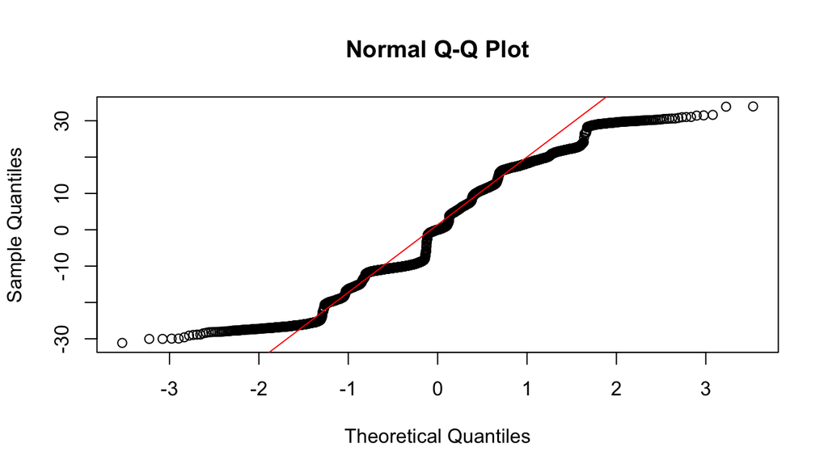

```r
qqnorm(resid(lme.conv))
qqline(resid(lme.conv), col = "red")
```

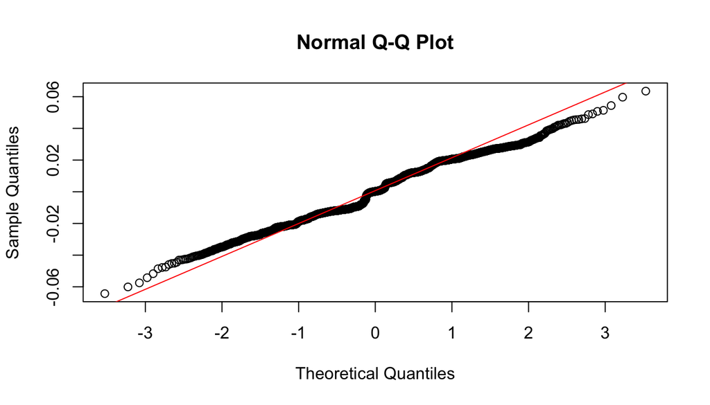

[output not shown]

[output not shown]

```r
lme.log = lmer(log(rt) ~ group * session + (1 + session | participant) + (1 | item), data = data)

qqnorm(resid(lme.log))
qqline(resid(lme.log), col = "red")
```

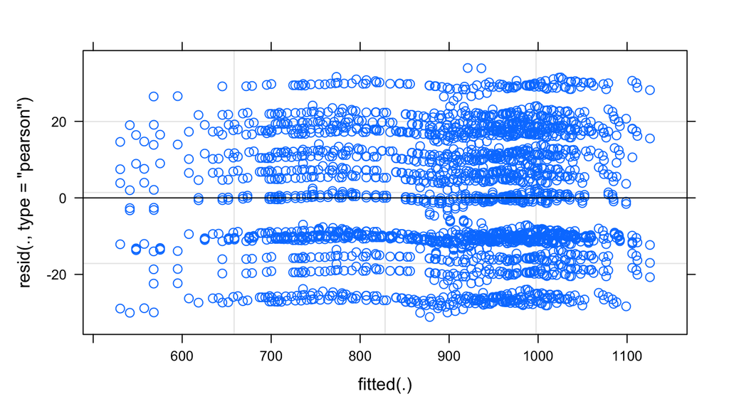

```r
plot(lme.conv)
```

## 7.3 normality of random intercept, random slopes

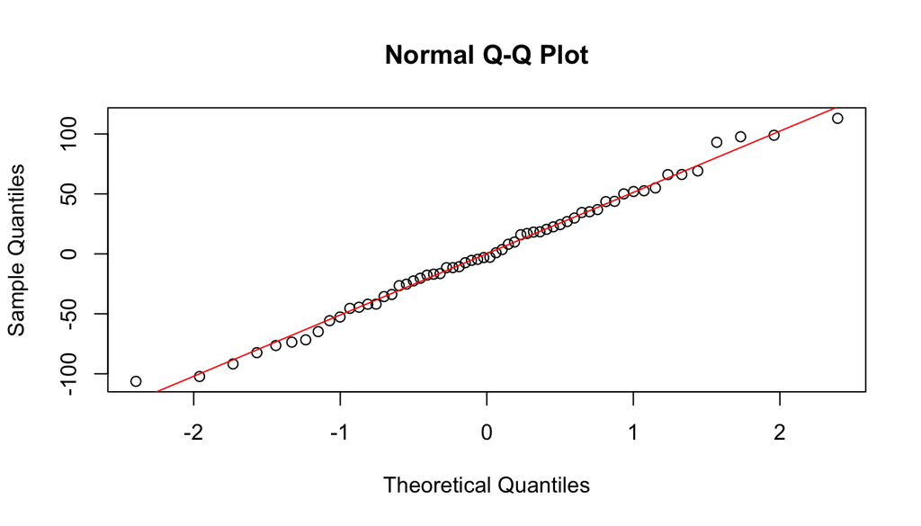

```r
qqnorm(ranef(lme.conv)$participant[,1] )
qqline(ranef(lme.conv)$participant[,1], col = "red")
```

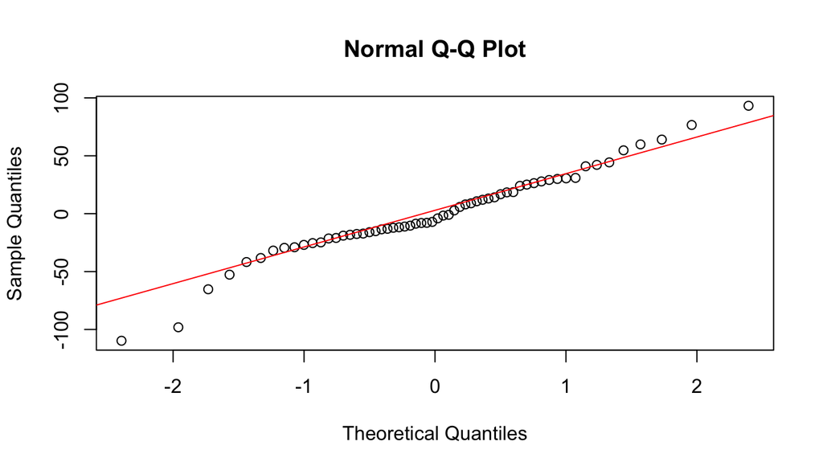

```r
qqnorm(ranef(lme.conv)$participant[,2] )
qqline(ranef(lme.conv)$participant[,2], col = "red")
```

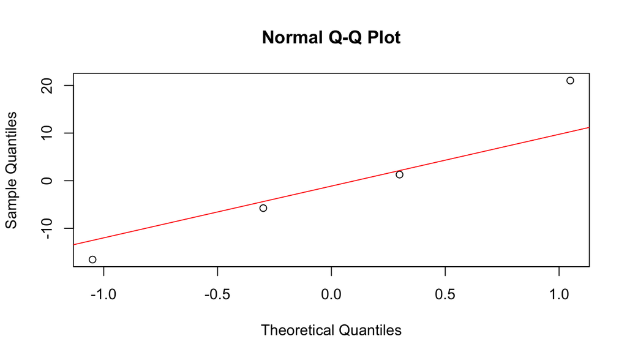

```r
qqnorm(ranef(lme.conv)$item[,1] )
qqline(ranef(lme.conv)$item[,1], col = "red")
```